# NBIS Report

31-May-2022

**NBIS ID:** SMS_6198  
**Report Version:** 1.0  
**Request by:** Mona N. Högberg (mona.n.hogberg@slu.se)  
**Principal Investigator:** Mona N. Högberg (mona.n.hogberg@slu.se)  
**Organisation:** SLU  
**NBIS Staff:** Juliana Assis (juliana.assis@nbis.se)

# 1 Setup

```r
## LIBRARIES
library("dada2")
library("devtools")
library("dplyr")
library("ggplot2")
library("microbiome")
library("phangorn")
library("phyloseq")
library("Rcpp")
library("reshape2")
library("tidyr")
library("vegan")
library("ShortRead")
library("Biostrings")
library("DECIPHER")
library("SensusR")
library("gplots")
library("gridExtra")
library("grid")
library("ggpubr")
library("reshape2")
library("reshape")
library("lulu")
library("ggrepel")
library("ggh4x")
library("RColorBrewer")
```

# 2 Version

1.0

- Support Request  
  Request sent by the user: Mona N. Högberg

# 3 Data

96 samples

- Type of data

ITS amplicon

- Data location rackham.uppmax.uu.se /proj/snic2022-22-352
- Uppmax project ID SNIC 2022/22-352
- NGI Project ID P9723
- Database used Unite

# 4 Tools

NFCore-Ampliseq (Dada2)

```r
#Sample Info
head(sample_info_tab)
```

|  | NGI_ID | User_ID | Mreads | Q30 | Sample_ID_O | Site | Transect | Ecotype | Type | Main_Analysis |
| --- | --- | --- | --- | --- | --- | --- | --- | --- | --- | --- |
| P9723_1001_S1_L001 | P9723_1001 | 3a | 0.02 | 71.46.00 | 3 | I | 1 | Meadow | A | Yes |
| P9723_1002_S2_L001 | P9723_1002 | 23a | 0.26 | 70.55.00 | 23 | V | 1 | Pine | A | Yes |
| P9723_1003_S3_L001 | P9723_1003 | 43a | 0.28 | 69.03.00 | 43 | IV | 2 | Spruce | A | Yes |
| P9723_1004_S4_L001 | P9723_1004 | 63a | 0.02 | 69.63 | 63 | III | 3 | Spruce-Alder | A | Yes |
| P9723_1005_S5_L001 | P9723_1005 | 3b | 0.22 | 69.71 | 3 | I | 1 | Meadow | B | No |
| P9723_1006_S6_L001 | P9723_1006 | 23b | 0.27 | 70.34.00 | 23 | V | 1 | Pine | B | No |

# 5 Workflow

## 5.1 Replicates Evaluation

Alpha Diversity Plot comparing the Replicates A and B.

Quality control analysis using matched samples from 3 different Transects: A, B and C of the experiment and replicates samples on each Ecotype. Comparison of alpha diversity in technical replicates samples on all Ecotypes from each Transect. ASV richness and ASV Shannon diversity.

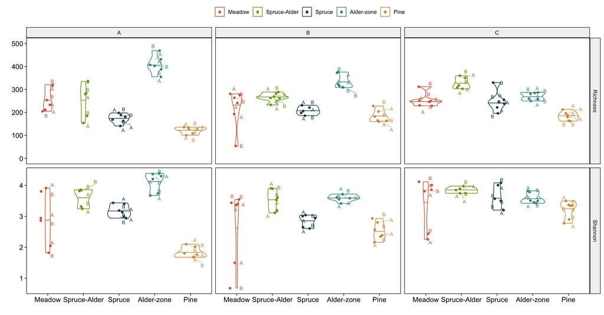

- Beta Diversity Plot comparing the Replicates A and B.

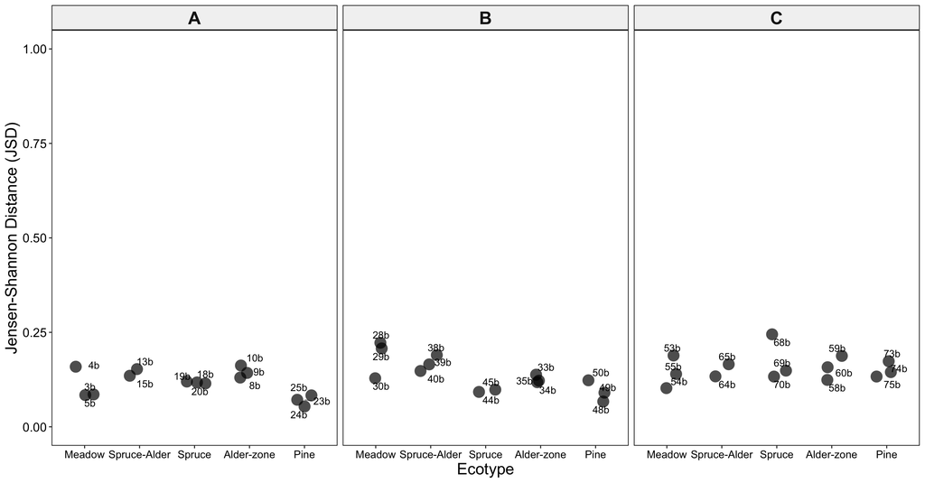

* Beta Diversity Plot comparing the Replicates A and B.

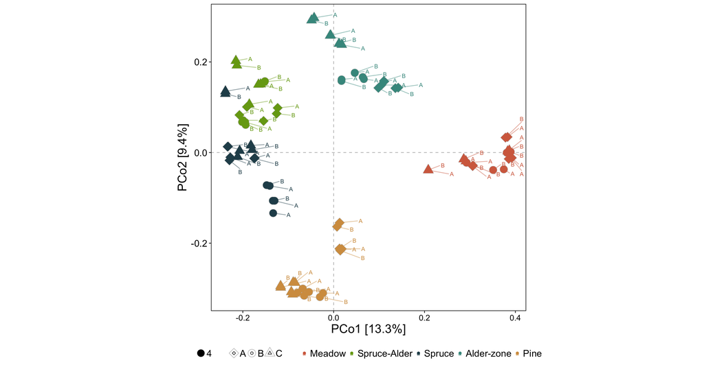

## 5.2 Main Analysis

- Alpha Diversity Plot - A.

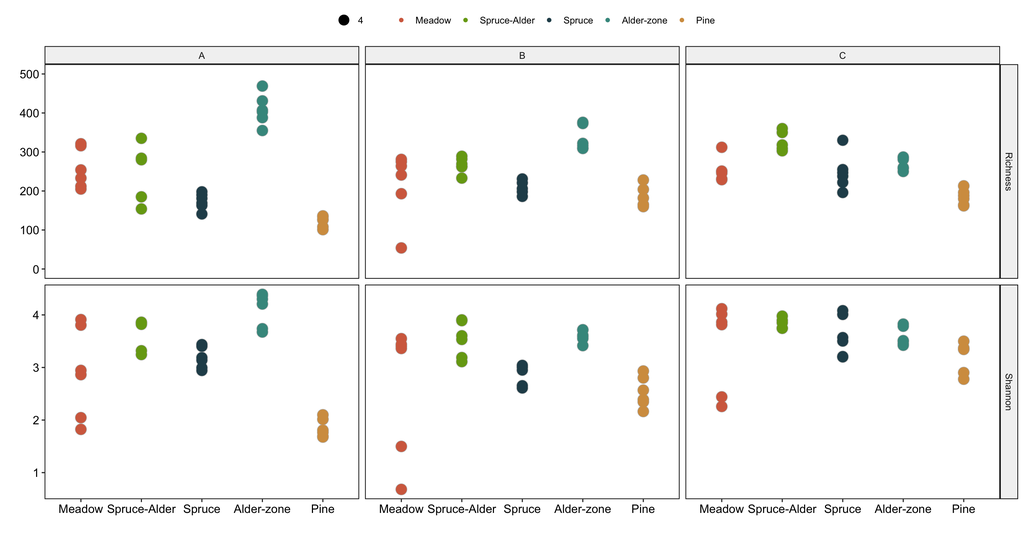

* Beta Diversity Plot - A.

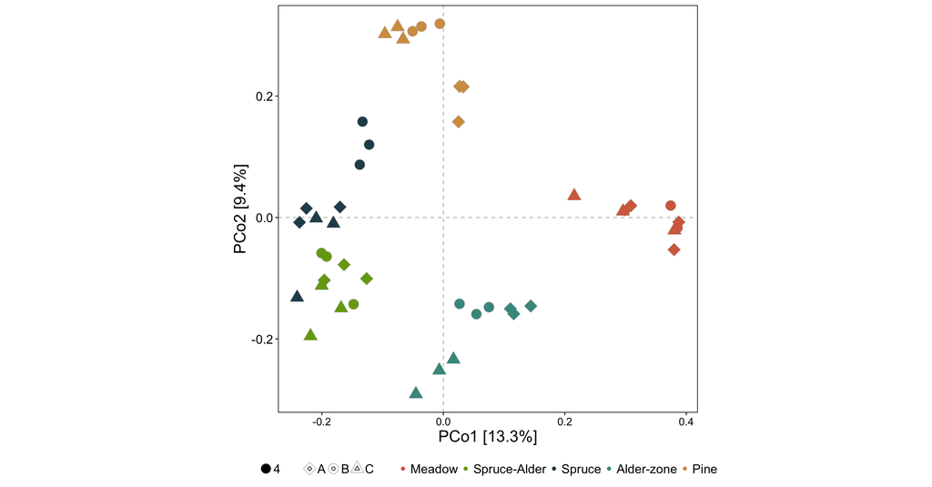

* Beta Diversity Plot - B.

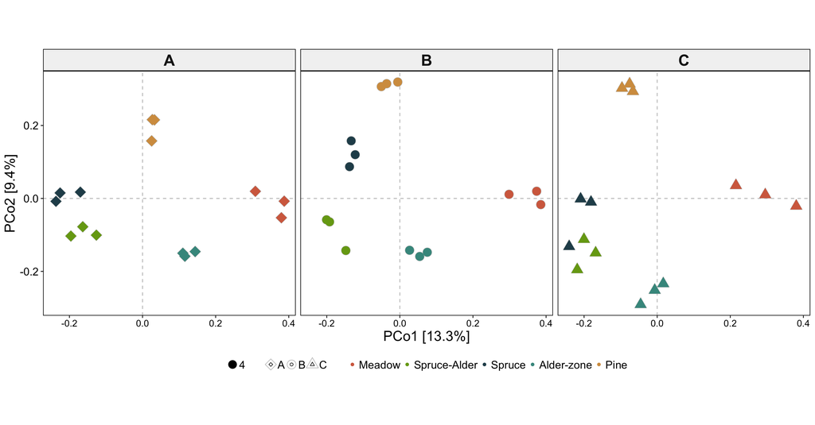

* Permutational analysis of variance

|  | Df | SumOfSqs | R2 | F | Pr(>F) |
| --- | --- | --- | --- | --- | --- |
| Ecotype | 4 | 4.0468610 | 0.30744219 | 4.555668 | 0.0001 |
| Transect | 1 | 0.4550809 | 0.03457274 | 2.049191 | 0.0021 |
| Residual | 39 | 8.6610562 | 0.65798507 | NA | NA |
| Total | 44 | 13.1629981 | 1.00000000 | NA | NA |

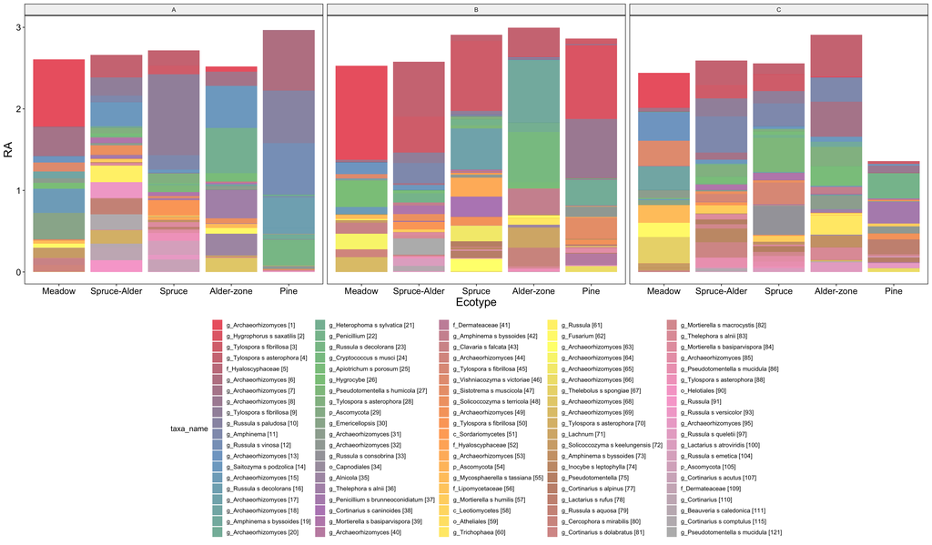